# Soluciones a problemas de *Time Series Analysis and its Applications* de Shumway y Stoffer

Es interesante que al realizar las pruebas sobre la serie `globtemp` luego de realizar una primera diferencia, todas las pruebas son significativas, indicadno que la serie diferenciada si es estacioanria. Además, la prueba ADF se hace usando $k=1$, lo cual toma en cuenta la autocorrelación con respecto al retraso $h=2$ en la serie sin diferenciar.

```r
list(
      df=tseries::adf.test(diff(globtemp), k=0),
      adf=tseries::adf.test(diff(globtemp), k=1),
      pp=tseries::pp.test(diff(globtemp))) |>
  map(broom::tidy) |>
  list_rbind() |>
  select(method, statistic:parameter) |>
  kbl(
    col.names=c("Prueba", "Estadístico", "$p$", "df"),
    escape=FALSE,
    caption="Estadísticos de las pruebas de Raíz unitaria para estacionaridad."
  )
```

Table 9: Estadísticos de las pruebas de Raíz unitaria para estacionaridad.

| Prueba | Estadístico | $p$ | df |
| --- | --- | --- | --- |
| Augmented Dickey-Fuller Test | -14,67630 | 0,01 | 0 |
| Augmented Dickey-Fuller Test | -11,90951 | 0,01 | 1 |
| Phillips-Perron Unit Root Test | -135,88521 | 0,01 | 4 |

**Problema 5.7** El paquete `stats` de R contiene los precios de cierre diarios de los cuatro principales índices bursátiles europeos; escriba `help(EuStockMarkets)` para obtener más detalles. Ajuste un modelo $GARCH$ a los rendimientos de una de estas series y discuta sus hallazgos. (Nota: el conjunto de datos contiene valores reales y no retornos. Por lo tanto, los datos deben transformarse antes del ajuste del modelo).

```r
EU_SMI <- EuStockMarkets[, "SMI"] %>%
  as_tsibble() %>%
  mutate(dates = lubridate::date(index), .before = 2) %>%
  index_by(dates) %>%
  summarise(
    smi_difflog = value
  ) %>%
  mutate(smi_difflog = difference(log(smi_difflog))) %>%
  slice(-1) %>%
  complete(dates = seq(min(dates), max(dates), by = "day")) %>%
  mutate(smi_difflog=zoo::na.approx(smi_difflog)) %>%
  as_tsibble()
```

Para el análisis se seleccionó el indice bursátil correspondiente a Suiza (SMI). Al revisar la serie se nota de inmediato que la serie contiene `NA`, introducidos de forma alternativa cada 2 a 3 días. Estos datos faltantes se imputaron usando interpolación lineal.

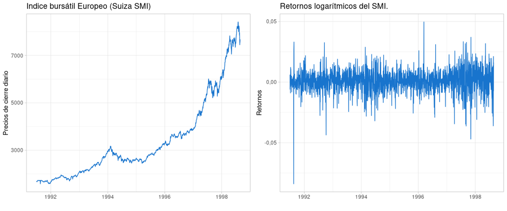

Figure 12: Indice bursátil de Suiza.

```r
cowplot::plot_grid(
    EuStockMarkets[, "SMI"] %>%
    as_tsibble() %>%
      autoplot(, colour="dodgerblue3") +
        theme_light() +
        xlab("") + ylab("Precios de cierre diario") +
        ggtitle("Indice bursátil Europeo (Suiza SMI)"),
    EU_SMI %>%
      autoplot(smi_difflog, colour="dodgerblue3") +
        theme_light() +
        xlab("") + ylab("Retornos") +
        ggtitle("Retornos logarítmicos del SMI."),
    nrow=1)
```

Figura 23. Indice bursátil de Suiza.

El indice bursátil correspondiente a Suiza (SMI), el cual se muestra en la figura 25, junto a los retornos calculados a partir de la misma. La serie tiene una tendencia creciente clara que se elimina al calcular los retornos, con caídas importantes durante todo el año 1994, y a la mitad del año 1997. Es en estos momentos es que se observan los *clusters* de volatilidad más importantes de la serie de retornos.

La ACF y PACF muestran que los retornos parecen ser generados por un proceso autoregresivo de primer o segundo orden en el componente ARMA, y se observan múltiples correlaciones pequeñas, pero significativas, que pueden resultar de la volatilidad cambiante.  
La volatilidad se observa a la derecha en la misma figura, la cual se calcula usando una ventana de un mes, y presenta un comportamiento bastante fluctuante, con crestas particularmente grandes durante los años 1994 y 1997.

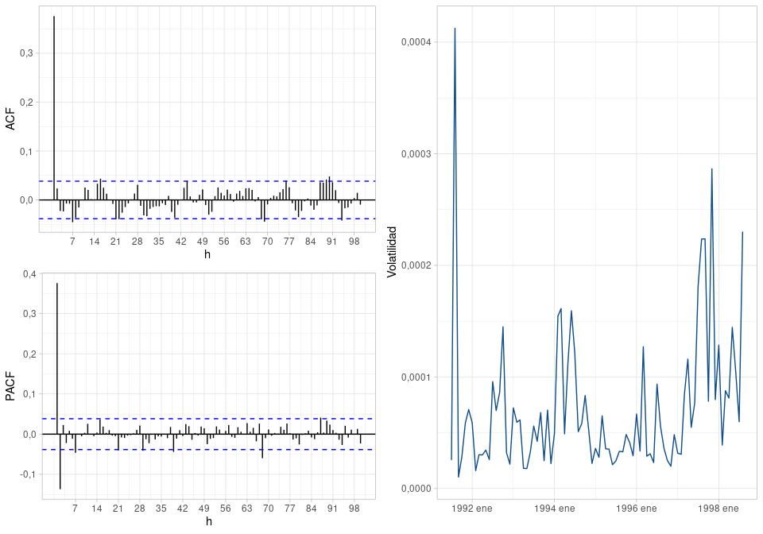

Figure 13: Funciones de autocorrelación y autocorrelación parcial para los retornos (a la izquierda) y volatilidad mensual de los retornos.

```r
monthly_aggregates <- EU_SMI %>%
  index_by(year_month = ~ yearmonth(.)) %>%
  summarise(
    month_var = var(smi_difflog, na.rm = TRUE),
    month_mean_return = mean(smi_difflog ** 2, na.rm = TRUE))

cowplot::plot_grid(
    cowplot::plot_grid(
        EU_SMI %>%
          ACF(smi_difflog, lag_max=100) %>%
          autoplot() +
            xlab("h") +
            ylab("ACF") +
            theme_light(),
        EU_SMI %>%
          PACF(smi_difflog, lag_max=100) %>%
          autoplot() +
            xlab("h") +
            ylab("PACF") +
            theme_light(),
        ncol=1),
    monthly_aggregates %>%
      autoplot(month_var, colour = "dodgerblue4") +
      theme_light() +
      ylab("Volatilidad") +
      xlab(""),
  nrow=1)
```

Figura 24. Funciones de autocorrelación y autocorrelación parcial para los retornos (a la izquierda) y volatilidad mensual de los retornos.

El siguiente fragmento de código muestra los resultados de la prueba Arch por multiplicadores de Lagrange, al descomponer la varianza de la serie e identificar si sus rezagos son significativos:

```r
arch_test <- EU_SMI %$%
  FinTS::ArchTest(smi_difflog, lags = 4, demean = FALSE)
```

de lo que se obtiene que la serie tiene efectos Arch significativos ($\chi^2=$ 280,47, $p=$ 0 ), y que existe una correlación importante entre la varianza y los retornos cuadrados.

Se procede a ajustar modelos GARCH para la volatilidad, con componente $ARCH(1)$ y $ARCH(2)$ solamente, y con volatilidad independiente de sus retrasos, y regresada sobre retrasos $h=1$ y $2$. Además, se prueban estos modelos usando la posibilidad de un modelo ARMA para la media con componente autoregresivo de primer o segundo orden.

```r
ARMA_mod <- rep(c("ARMA(1, 0)", "ARMA(2, 0)"), each=4)
GARCH_mod <- rep(c("GARCH(1,0)", "GARCH(1,1)", "GARCH(2,1)", "GARCH(2,2)"), 2)
arma_pars <- rep(list(fisrt_order=c(1,0), second_order=c(2,0)), each=4)
garch_mod_pars <- rep(list(c(1, 0), c(1, 1), c(2, 1), c(2, 2)), 2)

garch_fitting <- tibble(
    ARMA_mod, GARCH_mod,
    arma_mod=arma_pars,
  garch_mod=garch_mod_pars) %>%
  mutate(
    garch_mods_spec=map2(
        arma_mod, garch_mod,
      ~ugarchspec(
        mean.model = list(
            armaOrder=.x,
            include.mean = FALSE),
        variance.model=list(model = "sGARCH", garchOrder=.y),
        distribution.model = "norm")
    ),
    garch_mods_fit=map(garch_mods_spec,
      ~ugarchfit(., EU_SMI)),
    convergence=map_dbl(garch_mods_fit, convergence)
  ) %>%
  filter(convergence == 0)
```

En total, se ajustan 8 modelos, de los cuales solo el modelo $GARCH(1,0)$ con componente $ARMA(1,0)$ para la media, fallo en converger. En la tabla tabla 8 se muestran los resultados de los criterios de información para el resto de los modelos ajustados, donde se observa que los mejores modelos, de acuerdo al AIC, son los $GARCH(2,2)$, tanto para el componente $ARMA(1,0)$ como para $ARMA(2,0)$; seguido de los modelos con componente $ARMA(2,0)$ y componente $GARCH(1, 1)$ y $GARCH(2, 1)$. La misma tendencia se sigue del resto de los criterios de información mostrados en la tabla.

```r
garch_fitting %>%
  mutate(glanced=map(garch_mods_fit, infocriteria), .after=2) %>%
  unnest(glanced) %>%
  mutate(criteria=rep(c("AIC", "BIC", "Shibata", "Hannan-Quinn"), 7), .after=2) %>%
  select(1:4) %>%
  spread(key="criteria", value=4) %>%
  arrange(AIC) %>%
  slice(1:5) %>%
  kbl(digits = 3,
    caption="Criterios de información para 5 de los modelos GARCH ajustados.")
```

Table 10: Criterios de información para 5 de los modelos GARCH ajustados.

| ARMA_mod | GARCH_mod | AIC | BIC | Hannan-Quinn | Shibata |
| --- | --- | --- | --- | --- | --- |
| ARMA(2, 0) | GARCH(2,2) | -7,026 | -7,010 | -7,020 | -7,026 |
| ARMA(1, 0) | GARCH(2,2) | -7,011 | -6,998 | -7,006 | -7,011 |
| ARMA(2, 0) | GARCH(1,1) | -6,999 | -6,988 | -6,995 | -6,999 |
| ARMA(2, 0) | GARCH(2,1) | -6,998 | -6,985 | -6,993 | -6,998 |
| ARMA(1, 0) | GARCH(1,1) | -6,988 | -6,979 | -6,985 | -6,988 |

Sin embargo, al verificar los coeficientes de los modelos $GARCH(2,2)$ y $GARCH(2,1)$, se obtiene que los coeficientes $\\alpha_2$ no son significativos (resultado no mostrado). Es por ello que se escoge el modelo $GARCH(1,1)$ con componente $ARMA(2,0)$, dados los criterios de información mostrados antes. Los coeficientes de este modelo se muestran a continuación.

```r
garch_fitting %>%
  mutate(tidied=map(garch_mods_fit,
    \(x) {
    x@fit$matcoef %>%
      as_tibble()
  }), .after=2) %>%
  unnest(tidied) %>%
  filter(ARMA_mod == "ARMA(2, 0)" & GARCH_mod == "GARCH(1,1)") %>%
  mutate(
    criteria=c("$\\phi_1$", "$\\phi_2$", "$\\alpha_0$", "$\\alpha_1$", "$\\beta$"),
    .after=2) %>%
  select(criteria:`Pr(>|t|)`) %>%
  kbl(digits = c(NA, 6, 7, 2, 4),
    escape=FALSE,
    col.names=c("Coef.", "Estimado", "Desv. Estand.", "$t$", "$p$"),
    caption="Coeficientes estimados para el modelo ARMA(2,0) con GARCH(1,1).")
```

Table 11: Coeficientes estimados para el modelo ARMA(2,0) con GARCH(1,1).

| Coef. | Estimado | Desv. Estand. | $t$ | $p$ |
| --- | --- | --- | --- | --- |
| $\phi_1$ | 0,442653 | 0,0211138 | 20,97 | 0 |
| $\phi_2$ | -0,114352 | 0,0211563 | -5,41 | 0 |
| $\alpha_0$ | 0,000007 | 0,0000002 | 27,57 | 0 |
| $\alpha_1$ | 0,174565 | 0,0138680 | 12,59 | 0 |
| $\beta$ | 0,721929 | 0,0141531 | 51,01 | 0 |

El modelo final escogido se escribe entonces:

$$\begin{aligned}
r_t &= \phi_1 r_{t-1} + \phi_2 r_{t-2} + \sigma_t\epsilon_t \\
\sigma_t &= \alpha_0 + \alpha_1 r_{t-1} + \beta \sigma_{t-1}
\end{aligned}$$

donde $\epsilon_t \sim N(0, 1)$. Los residuales, tal como se observan en la figura 27, donde se observa que ya no hay correlaciones importantes en las ACF y PACF, pero los residuales no se distribuyen normalmente, sino que parecen seguir una $t$-Student simétrica.

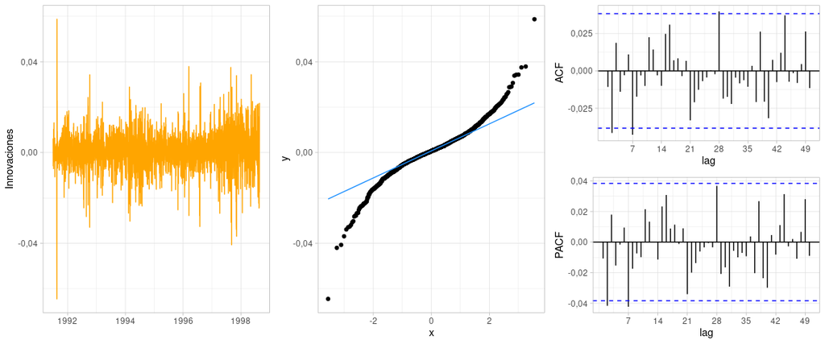

Figure 14: Gráficos diagnósticos de residuales.

```r
residuals_garch <- garch_fitting %>%
  filter(ARMA_mod == "ARMA(2, 0)" & GARCH_mod == "GARCH(1,1)") %$%
  residuals(garch_mods_fit[[1]]) %>%
  zoo::fortify.zoo() %>%
  as_tsibble()

cowplot::plot_grid(
  autoplot(residuals_garch, ., colour="orange") +
    theme_light() + xlab("") + ylab("Innovaciones"),
  residuals_garch %>%
    ggplot(aes(sample = .)) +
    stat_qq() + stat_qq_line(color="dodgerblue") +
    theme_light(),
  cowplot::plot_grid(
    ACF(residuals_garch, ., lag_max=50) %>%
      autoplot() + theme_light() +
      xlab("lag") + ylab("ACF"),
    PACF(residuals_garch, ., lag_max=50) %>%
      autoplot() + theme_light() +
      xlab("lag") + ylab("PACF"),
    nrow=2
  ),
  nrow=1
)
```

Figura 25. Gráficos diagnósticos de residuales.

Al realizar un ultimo ajuste del modelo $GARCH(1,1)$ con modelo para la media $ARMA(2,0)$, y usando como modelo de distribución una $t$-Student, se obtienen criterios de información menores que los encontrados para los modelos anteriores, indicando una preferencia por el nuevo modelo. Los coeficientes estimados se muestran en la siguiente tabla:

```r
final_spec <- ugarchspec(
  mean.model = list(
    armaOrder=c(2, 0),
    include.mean = FALSE),
  variance.model=list(
    model = "sGARCH",
    garchOrder=c(1,1)),
  distribution.model = "std")

final_fit <- ugarchfit(final_spec, EU_SMI)
final_coefs <- final_fit@fit$matcoef

final_coefs %>%
  as_tibble() %>%
  mutate(Coef=c("$\\phi_1$", "$\\phi_2$", "$\\alpha_0$", "$\\alpha_1$", "$\\beta$", "shape"), .before=1) %>%
  kbl(digits = c(NA, 5, 6, 2, 4),
    escape=FALSE,
    col.names=c("Coef.", "Estimado", "Desv. Estand.", "$t$", "$p$"),
    caption="Coeficientes estimados para el modelo ARMA(2,0) con GARCH(1,1)."
  )
```

Table 12: Coeficientes estimados para el modelo ARMA(2,0) con GARCH(1,1).

| Coef. | Estimado | Desv. Estand. | $t$ | $p$ |
| --- | --- | --- | --- | --- |
| $\phi_1$ | 0,53257 | 0,022174 | 24,02 | 0,0000 |
| $\phi_2$ | -0,11589 | 0,016532 | -7,01 | 0,0000 |
| $\alpha_0$ | 0,00003 | 0,000002 | 14,02 | 0,0000 |
| $\alpha_1$ | 0,67608 | 0,080122 | 8,44 | 0,0000 |
| $\beta$ | 0,01382 | 0,017169 | 0,80 | 0,4209 |
| shape | 4,97331 | 0,483095 | 10,29 | 0,0000 |

De los valores de probabilidad se tiene que en este caso, el modelo no necesita de términos retrasados de la volatilidad, dado que $\\beta$ no es significativamente distinto de cero, por lo que el modelo se puede escribir como uno con solo componente $Arch(1)$:

$$\begin{aligned}
r_t &= 0,533_{(0,022)} r_{t-1} -0,116_{(0,017)} r_{t-2} + \sigma_t\epsilon_t \\
\sigma_t &= 0,00003_{(0,000002)} + 0,676_{(0,08)} r_{t-1}
\end{aligned}$$

con $\epsilon \sim t(\sim 5)$. El gráfico de los retornos versus la volatilidad muestra que el modelo es capaz de toma en cuenta las desviaciones en la serie; y el gráfico *QQ* muestra que al usar como modelo teórico la distribución $t(5)$, las observaciones se ajustan muy bien a la recta.

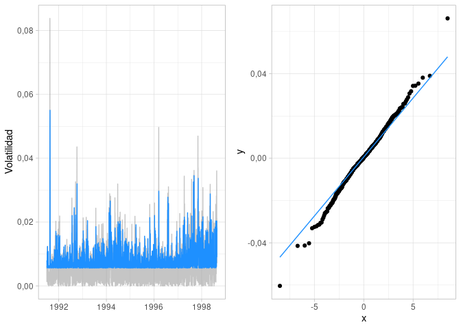

```r
residuals_garch <- residuals(final_fit) %>%
  zoo::fortify.zoo() %>%
  as_tsibble()

cowplot::plot_grid(
  EU_SMI %>%
    mutate(abs_returns = abs(smi_difflog)) %>%
    autoplot(abs_returns, colour="200", alpha = .6) +
    autolayer(sigma(final_fit) %>%
      zoo::fortify.zoo() %>%
      as_tsibble(), ., colour="dodgerblue", linewidth = .5) +
    theme_light() +
    ylab("Volatilidad") + xlab(""),
  residuals_garch %>%
    ggplot(aes(sample = .)) +
    stat_qq(distribution=stats::qt,
        dparams=list(df=4.97)) +
    stat_qq_line(distribution=stats::qt,
        dparams=list(df=4.97),
        color="dodgerblue") +
    theme_light(),
    nrow=1
)
```